# Rural deveplopment in the CAP: correlations at regional level

June 12th 2019

## What is Common Agricultural Policy (CAP)?

Market measures, income support and rural development

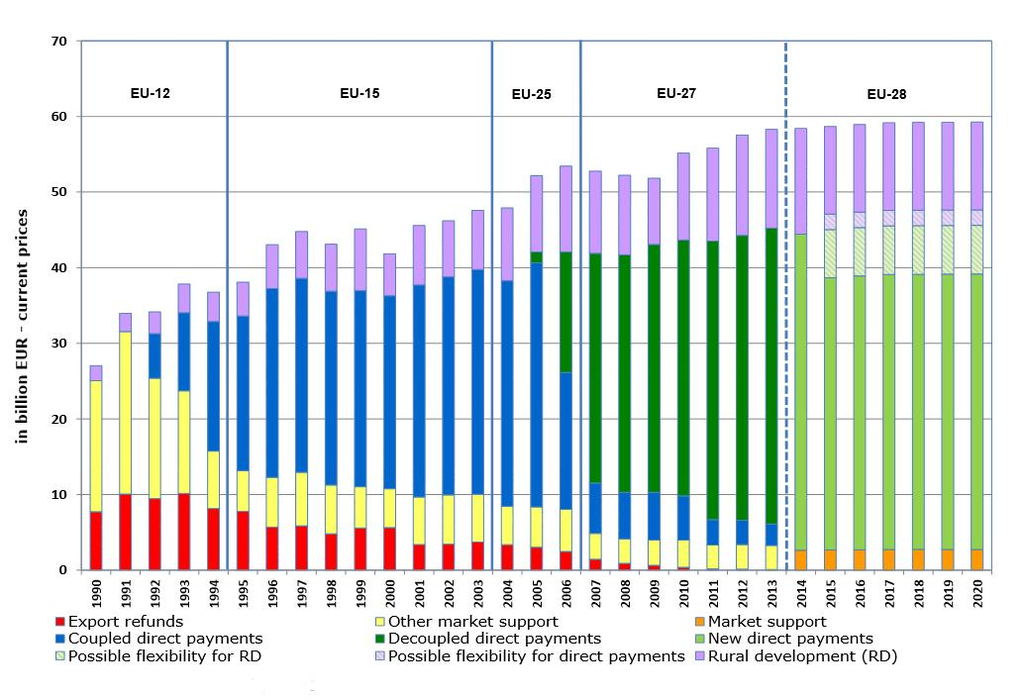

Pushkarev (2015)

# Research problem

## Regional development

Regional development ~ rural development.

Uneven regional development is caused by

- different productivity,
- different transportation infrastructure,
- technology and knowledge spillovers,
- factor mobility (Dall’erba (2005)).

## Rhetorics

Article 3. Mission

The EAFRD shall contribute to the Europe 2020 Strategy by promoting sustainable rural development throughout the Union in a manner that complements the other instruments of the CAP, the cohesion policy and the common fisheries policy. It shall contribute to the development of a Union agricultural sector that is more **territorially and environmentally balanced**, climate-friendly and resilient and competitive and innovative. It shall also contribute to the **development of rural territories**.

Article 4. Objectives

Within the overall framework of the CAP, support for rural development, including for activities in the food and non-food sector and in forestry, shall contribute to achieving the following objectives:

- fostering the competitiveness of agriculture;
- ensuring the sustainable management of natural resources, and climate action;
- achieving a **balanced territorial development of rural economies and communities** including the creation and maintenance of employment.

European Parliament and Council of the European Union (2013)

## Research

Territorial aspects have not been seriously considered in the policy design of the CAP nor Pillar 2 (Zasada et al. (2018)).

The impact of rural development support of CAP on the well-being of regions in Hungary has been demonstrated to be insignificant (Bakucs, Fertő, and Benedek (2019)).

Regions that are less rural tend to have higher Pillar 2 expenditure intensity compared to more rural regions (Camaioni et al. (2014)).

Distribution of funds from other regional policies have stronger association with regional disadvantage compared to Pillar 2 (Crescenzi, Filippis, and Pierangeli (2011)).

## Distribution of EAFRD expenditure

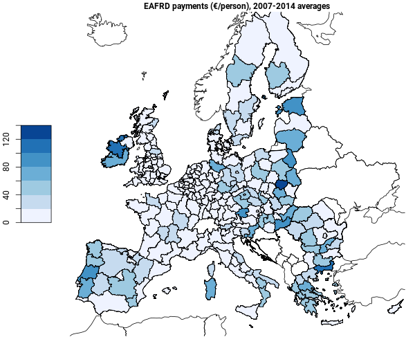

European Commission (2019)

The allocation principles of EAFRD expenditure are unclear.

The mechanism of allocation is different on country, region and beneficiary level.

Hence, there’s a lot of uncertainity and randomness.

Which factors and how are correlated to the rural development expenditure?

## Expected correlations

*Fostering the competitiveness of agriculture*: small farming, agricultural employment and investments.

*Ensuring the sustainable management of natural resources, and climate action*: organic farming.

*Achieving a balanced territorial development of rural economies and communities including the creation and maintenance of employment*: GDP, unemployment.

Correlation to other EU structural and investment funds.

Spatial correlation between regions.

# Data and methods

## Data

Amount of payments to each NUTS2 region between 1993-2015 from EAGGF, EAFRD and some other EU structural and investment funds.

Modelled yearly payments.

Other data on NUTS2 regions from Eurostat.

Expenditure per capita (€/person).

## Spatial weights

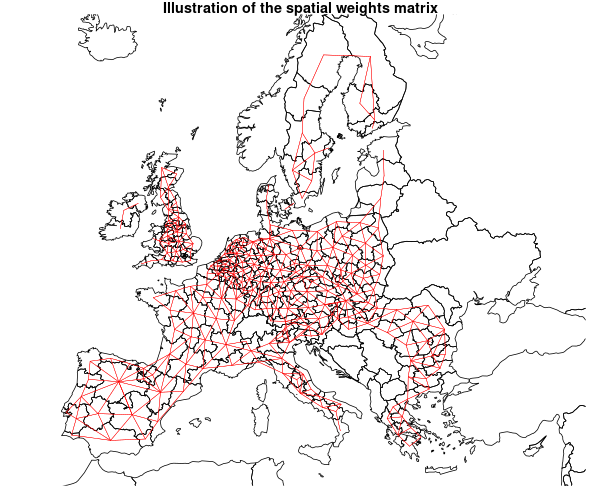

## Global indicator of spatial association

Moran’s I is defined as

$$I = \frac{n}{\sum_{i=1}^{n} \sum_{j=1}^{n} w_{i,j}} \frac{\sum_{i=1}^{n} \sum_{j=1}^{n} w_{i,j}(x_i - \bar{x})(x_j - \bar{x})}{\sum_{j=1}^{n}(x_i - \bar{x})^2}.$$

In case of queen contiguity $n = {\sum_{i=1}^{n} \sum_{j=1}^{n} w_{i,j}}$, thus Moran’s I is
$$I = \frac{\sum_{i=1}^{n} \sum_{j=1}^{n} w_{i,j}(x_i - \bar{x})(x_j - \bar{x})}{\sum_{j=1}^{n}(x_i - \bar{x})^2}.$$

## Local indicator of spatial association (LISA)

First defined by Anselin (1995) as

$$I_i = \frac{(x_i - \bar{x})}{(x_i - \bar{x})^2/n}\sum_{j}w_{i,j}(x_j - \bar{x}).$$

## Pearson’s correlation coefficient

The direction of causality is unclear and theoretically multidirectional.

$$r = \frac{\sum_{i=1}^{n}(x_i-\bar{x})(y_i-\bar{y})}{\sum_{i=1}^{n}(x_i-\bar{x})^2 \sum_{i=1}^{n}(y_i-\bar{y})^2}$$

# Results

## Global spatial autocorrelation

```
##  [1] ""
##  [2] "\tMoran I test under randomisation"
##  [3] ""
##  [4] "data:  paySf$eafrd.cap  "
##  [5] "weights: spatWts  n reduced by no-neighbour observations"
##  [6] "  "
##  [7] ""
##  [8] "Moran I statistic standard deviate = 10.116, p-value < 2.2e-16"
##  [9] "alternative hypothesis: greater"
## [10] "sample estimates:"
## [11] "Moran I statistic       Expectation          Variance "
## [12] "      0.458045643      -0.004048583       0.002086784 "
## [13] ""
```

Higher than the 0.201 estimated by Crescenzi, Filippis, and Pierangeli (2011).

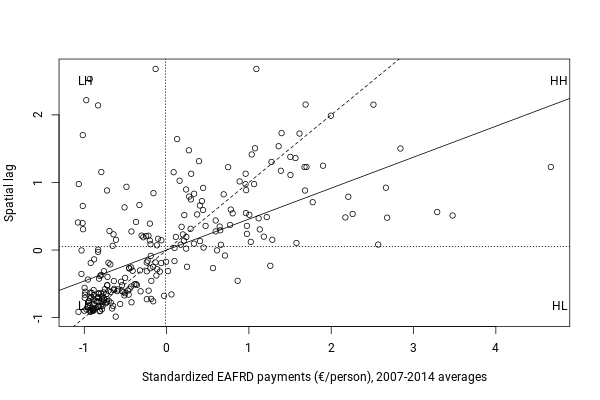

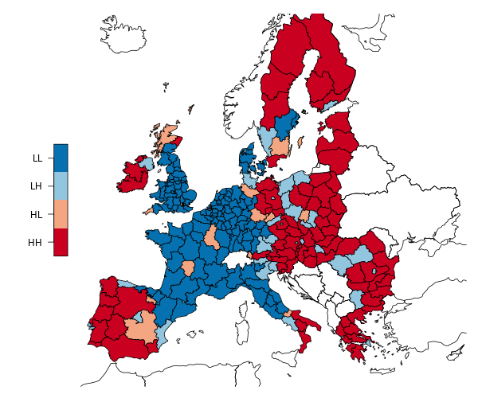

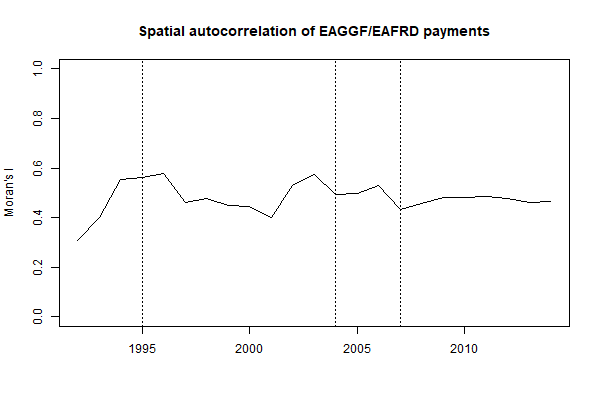

No negative trend as demonstrated by Crescenzi, Filippis, and Pierangeli (2011).

## Local spatial autocorrelation

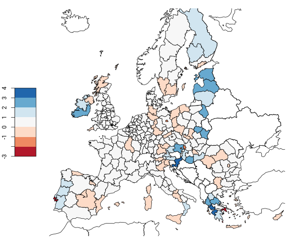

## Correlations with regional characteristics

**2007, 2010, 2013**

|  | r | p | r.1 | p.1 | r.2 | p.2 |
| --- | --- | --- | --- | --- | --- | --- |
| EAFRD payments (€/person) | 1 |  | 1 |  | 1 |  |
| GDP (1000 €/person) | -0.087 | 0.283 | -0.410 | 0.000 | -0.399 | 0.000 |
| Unemployment, ages 15-74 (%) | 0.042 | 0.604 | 0.046 | 0.571 | 0.015 | 0.848 |
| Share, holdings < 2 ha (%) | 0.012 | 0.884 | 0.218 | 0.006 | 0.366 | 0.000 |
| Area, holdings < 2 ha (%) | 0.059 | 0.465 | 0.027 | 0.737 | 0.112 | 0.164 |
| Employment, NACE2 A (%) | 0.252 | 0.002 | 0.588 | 0 | 0.701 | 0 |
| Investments, NACE2 A (%) | 0.411 | 0.000 | 0.563 | 0 | 0.573 | 0 |
| Share, organic holdings (%) | 0.385 | 0.000 | 0.255 | 0.001 | 0.184 | 0.022 |
| Area, organic holdings (%) | 0.323 | 0.000 | 0.284 | 0.000 | 0.217 | 0.007 |

## Correlations with other EU regional and investment funds

**2007, 2010, 2013**

|  | r | p | r.1 | p.1 | r.2 | p.2 |
| --- | --- | --- | --- | --- | --- | --- |
| EAFRD | 1 |  | 1 |  | 1 |  |
| Cohesion Fund | 0.227 | 0.027 | 0.432 | 0.000 | 0.361 | 0.000 |
| European Regional Development Fund | 0.639 | 0 | 0.657 | 0 | 0.675 | 0 |
| European Social Fund | 0.612 | 0 | 0.566 | 0 | 0.573 | 0 |

# Conclusions

Level of territorial aggregation may have a substantial impact on the results.

The concentration of expenditure is rather high at NUTS2 level.

There is no clear temporal trend in the concentration of expenditure.

Correlation between the expenditure and small farming, agricultural employment and investments has increased whereas it has weakened with organic production.

Other structural and investment funds of the EU are strongly correlated with the expenditure.

It has not been demonstrated that more support would lead to higher economic development.

So why the payments for rural development?

Is Pillar 2 an instrument to compensate for unequal Pillar 1 payments?

## Further research

Explaining the distribution instead of decribing it.

Expenditure form Pillar 1 and Member State co-financing.

Account for various differences between regions.

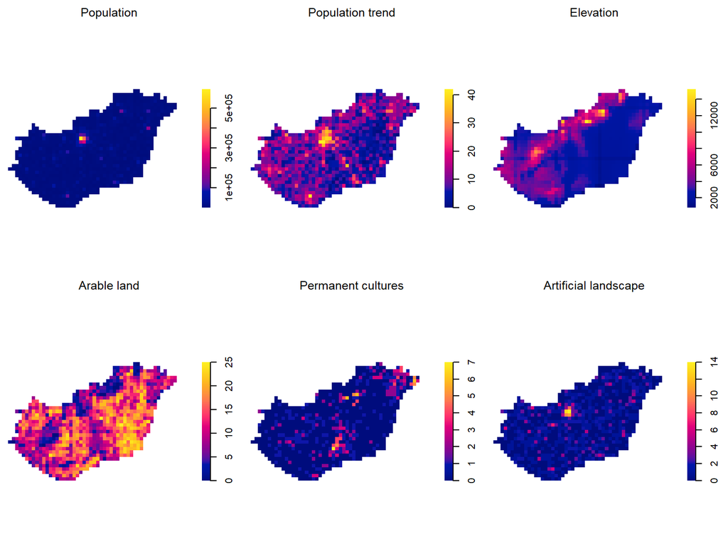

# That’s all!

For details see github.com/lillemets/19_uppsala.

# References

Anselin, Luc. 1995. “Local Indicators of Spatial Association-LISA.” *Geographical Analysis* 27 (2): 93–115. https://doi.org/10.1111/j.1538-4632.1995.tb00338.x.

Bakucs, Zoltán, Imre Fertő, and Zsófia Benedek. 2019. “Success or Waste of Taxpayer Money? Impact Assessment of Rural Development Programs in Hungary.” *Sustainability* 11 (7): 2158. https://doi.org/10.3390/su11072158.

Camaioni, Beatrice, Roberto Esposti, Francesco Pagliacci, and Franco Sotte. 2014. “How Does Space Affect the Allocation of the EU Rural Development Policy’s Expenditure? An Econometric Assessment.”

Crescenzi, Riccardo, Fabrizio De Filippis, and Fabio Pierangeli. 2011. “In Tandem for Cohesion? Synergies and Conflicts Between Regional and Agricultural Policies of the European Union.” Discussion Paper LEQS Paper No. 40/2011.

Dall’erba, Sandy. 2005. “Distribution of Regional Income and Regional Funds in Europe 1989–1999: An Exploratory Spatial Data Analysis.” *The Annals of Regional Science* 39 (1): 121–48. https://doi.org/10.1007/s00168-004-0199-4.

European Commission. 2019. “Historic EU Payments - Regionalised and Modelled Data European Structural and Investment Funds.” https://cohesiondata.ec.europa.eu/Other/Historic-EU-payments-regionalised-and-modelled/tc55-7ysv.

European Parliament and Council of the European Union. 2013. “Regulation (EU) No 1305/2013 of the European Parliament and of the Council of 17 December 2013 on Support for Rural Development by the European Agricultural Fund for Rural Development (EAFRD) and Repealing Council Regulation (EC) No 1698/2005.”

Pushkarev, Nikolai. 2015. “A CAP for Healthy Living. Mainstreaming Health into the EU Common Agricultural Policy.” *AIMS Public Health* 2 (4): 844–87. https://doi.org/10.3934/publichealth.2015.4.844.

Zasada, I., M. Weltin, M. Reutter, P. H. Verburg, and A. Piorr. 2018. “EU’s Rural Development Policy at the Regional Level—Are Expenditures for Natural Capital Linked with Territorial Needs?” *Land Use Policy* 77 (September): 344–53. https://doi.org/10.1016/j.landusepol.2018.05.053.